# Chapter 9 ARIMA

Author

Affiliation

Tyler George

Cornell College  
STA 364 Spring 2025 Block 5

## Setup

```r
library(patchwork)
library(purrr)
library(fpp3) # Primary
```

## ARIMA models

| **Component** | **Description** |
| --- | --- |
| **AR** | autoregressive (lagged observations as inputs) |
| **I** | integrated (differencing to make series stationary) |
| **MA** | moving average (lagged errors as inputs) |

. . .

**An ARIMA model is rarely interpretable in terms of visible data structures like trend and seasonality. But it can capture a huge range of time series patterns.**

# Stationarity and differencing

## Stationarity

**Definition** If $\{y_t\}$ is a stationary time series, then for all $s$, the distribution of $(y_t,\dots,y_{t+s})$ does not depend on $t$.

. . .

A **stationary series** is:

- roughly horizontal
- constant variance
- no patterns predictable in the long-term

## Stationary? (1/9)

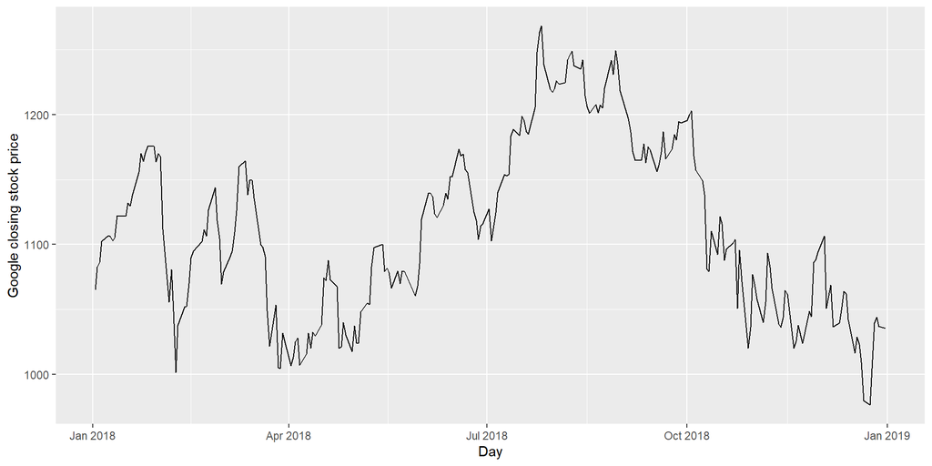

```r
gafa_stock |>
  filter(Symbol == "GOOG", year(Date) == 2018) |>
  autoplot(Close) +
  labs(y = "Google closing stock price", x = "Day")
```

## Stationary? (2/9)

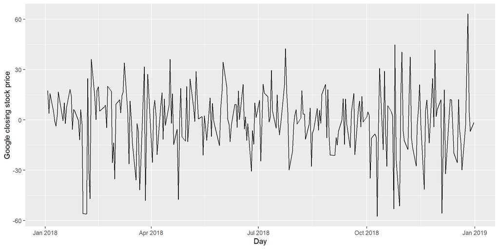

```r
gafa_stock |>
  filter(Symbol == "GOOG", year(Date) == 2018) |>
  autoplot(difference(Close)) +
  labs(y = "Google closing stock price", x = "Day")
```

## Stationary? (3/9)

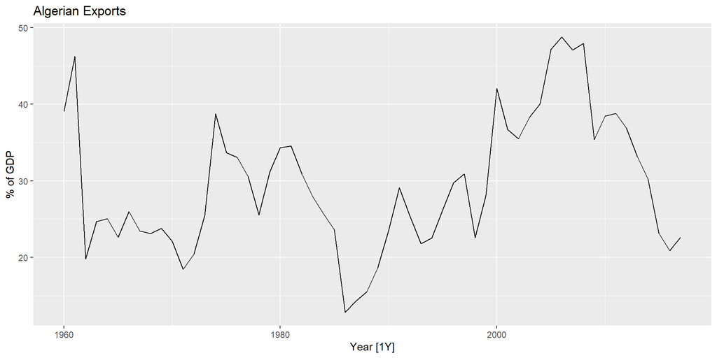

```r
global_economy |>
  filter(Country == "Algeria") |>
  autoplot(Exports) +
  labs(y = "% of GDP", title = "Algerian Exports")
```

## Stationary? (4/9)

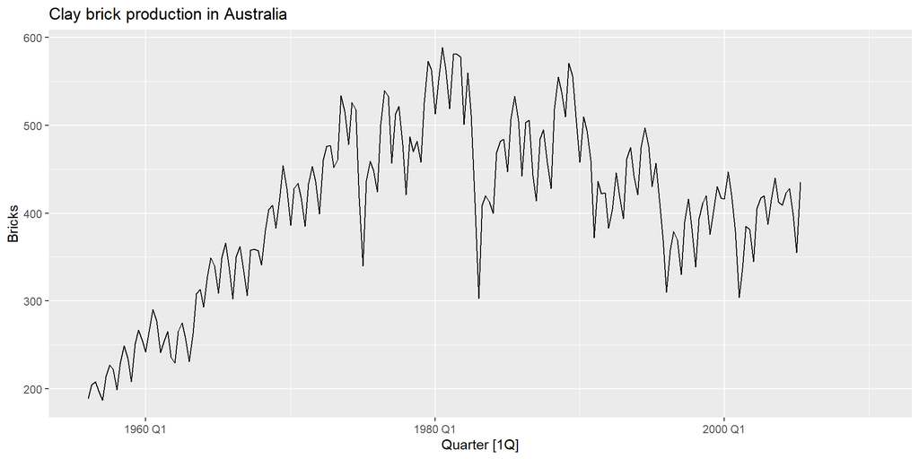

```r
aus_production |>
  autoplot(Bricks) +
  labs(title = "Clay brick production in Australia")
```

## Stationary? (5/9)

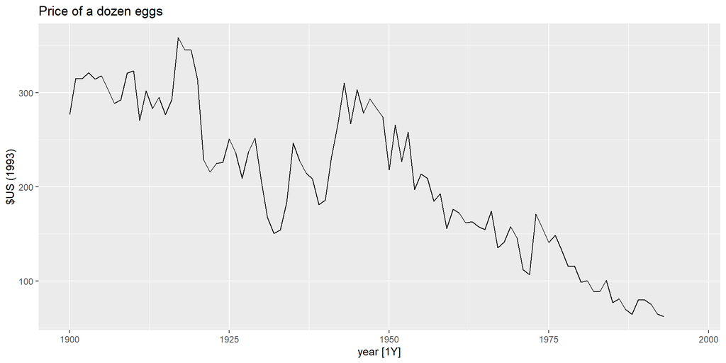

```r
prices |>
  filter(year >= 1900) |>
  autoplot(eggs) +
  labs(y="$US (1993)", title="Price of a dozen eggs")
```

## Stationary? (6/9)

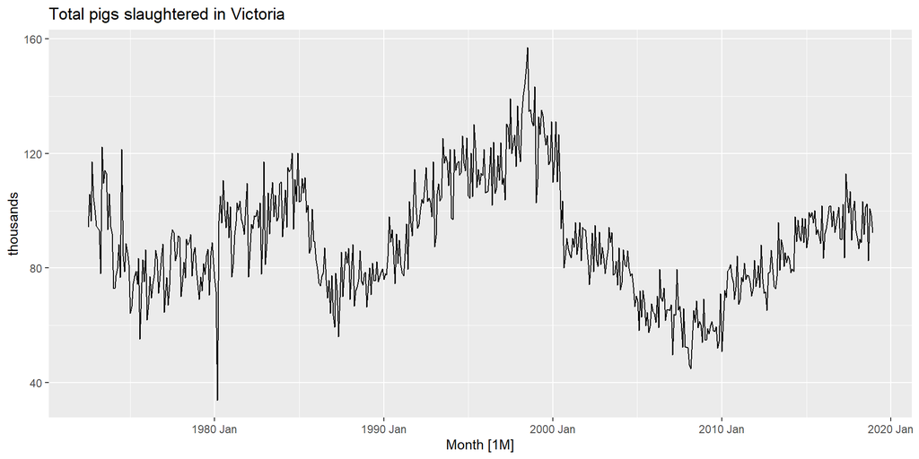

```r
aus_livestock |>
  filter(Animal == "Pigs", State == "Victoria") |>
  autoplot(Count/1e3) +
  labs(y = "thousands", title = "Total pigs slaughtered in Victoria")
```

## Stationary? (7/9)

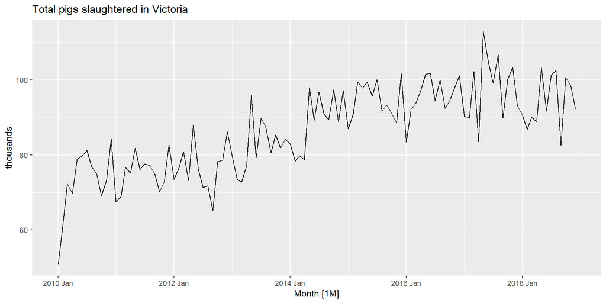

```r
aus_livestock |>
  filter(Animal == "Pigs", State == "Victoria", year(Month) >= 2010) |>
  autoplot(Count/1e3) +
  labs(y = "thousands", title = "Total pigs slaughtered in Victoria")
```

## Stationary? (8/9)

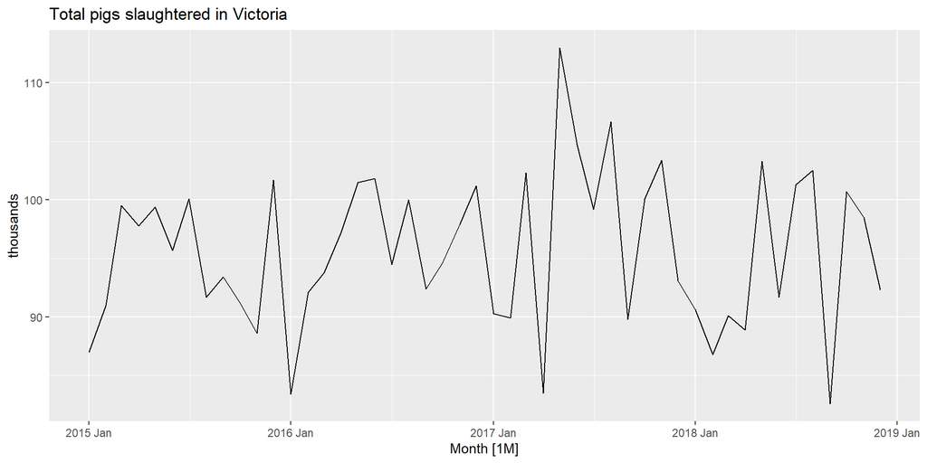

```r
aus_livestock |>
  filter(Animal == "Pigs", State == "Victoria", year(Month) >= 2015) |>
  autoplot(Count/1e3) +
  labs(y = "thousands", title = "Total pigs slaughtered in Victoria")
```

## Stationary? (9/9)

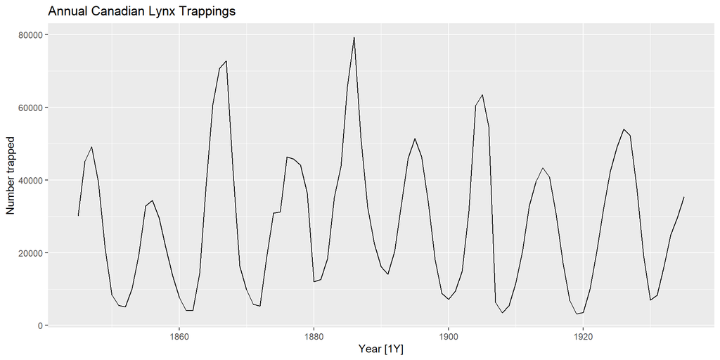

```r
pelt |>
  autoplot(Lynx) +
  labs(y = "Number trapped", title = "Annual Canadian Lynx Trappings")
```

## Stationarity

**Definition**

If $\{y_t\}$ is a stationary time series, then for all $s$, the distribution of $(y_t,\dots,y_{t+s})$ does not depend on $t$.

- Transformations help to **stabilize the variance**.
- For ARIMA modelling, we also need to **stabilize the mean**.

## Non-stationarity in the mean

**Identifying non-stationary series**

- time plot.
- The ACF of stationary data drops to zero relatively quickly
- The ACF of non-stationary data decreases slowly.
- For non-stationary data, the value of $r_1$ is often large and positive.

## Example: Google stock price (1/5)

```r
google_2018 <- gafa_stock |>
  filter(Symbol == "GOOG", year(Date) == 2018)
```

## Example: Google stock price (2/5)

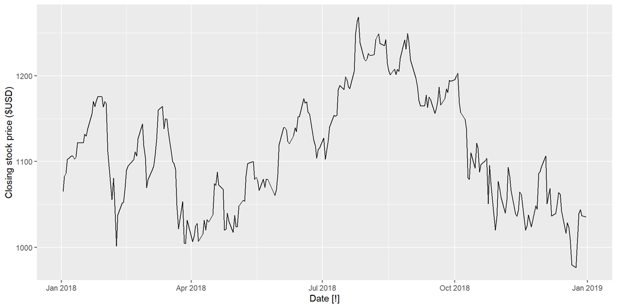

```r
google_2018 |>
  autoplot(Close) +
  labs(y = "Closing stock price ($USD)")
```

## Example: Google stock price (3/5)

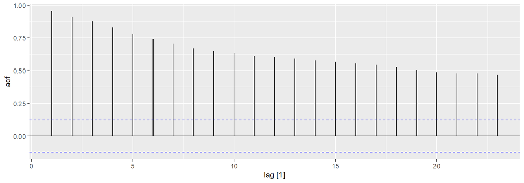

```r
google_2018 |> ACF(Close) |> autoplot()
```

## Example: Google stock price (4/5)

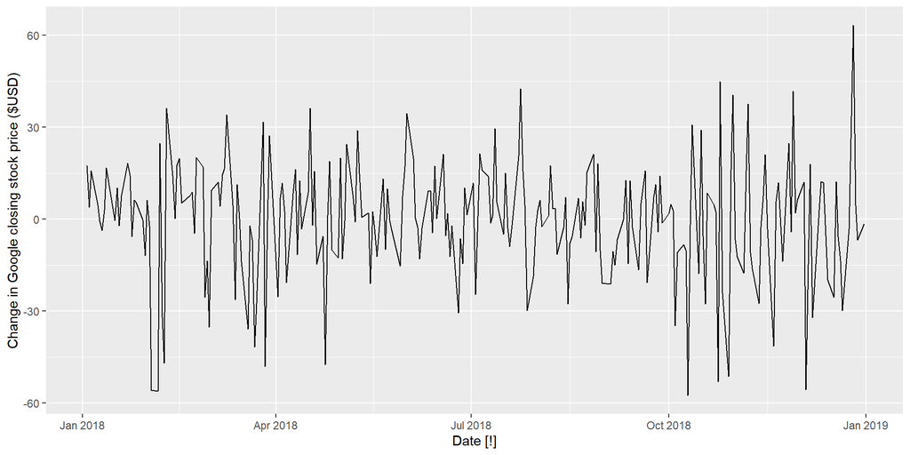

```r
google_2018 |>
  autoplot(difference(Close)) +
  labs(y = "Change in Google closing stock price ($USD)")
```

## Example: Google stock price (5/5)

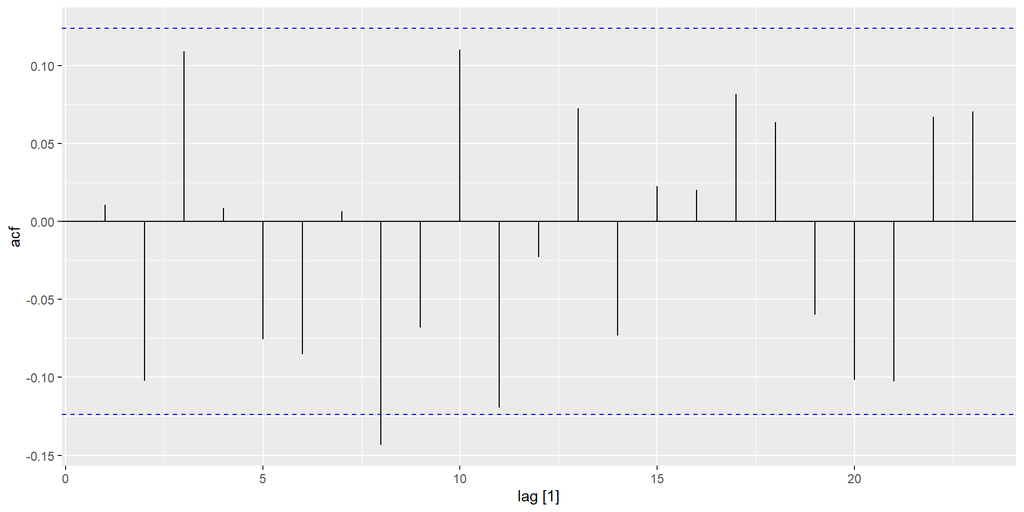

```r
google_2018 |> ACF(difference(Close)) |> autoplot()
```

## Differencing

- Differencing helps to **stabilize the mean**.
- The differenced series is the *change* between each observation in the original series: $y'_t = y_t - y_{t-1}$.
- The differenced series will have only $T-1$ values since it is not possible to calculate a difference $y_1'$ for the first observation.

## Random walk model

If differenced series is white noise with zero mean:

$y_t-y_{t-1}=\epsilon_t$ or $y_t=y_{t-1}+\epsilon_t$

where $\epsilon_t \sim NID(0,\sigma^2)$.

- Very widely used for non-stationary data.
- This is the model behind the **naïve method**.
- Random walks typically have:
  - long periods of apparent trends up or down
  - Sudden/unpredictable changes in direction
- Forecast are equal to the last observation
  - future movements up or down are equally likely.

## Random walk with drift model

If differenced series is white noise with non-zero mean:

$y_t-y_{t-1}=c+\epsilon_t$ or $y_t=c+y_{t-1}+\epsilon_t$}

where $\epsilon_t \sim NID(0,\sigma^2)$.

- $c$ is the **average change** between consecutive observations.
- If $c>0$, $y_t$ will tend to drift upwards and vice versa.
- This is the model behind the **drift method**.

## Second-order differencing

Occasionally the differenced data will not appear stationary and it may be necessary to difference the data a second time:

. . .

$$\begin{align*}
y''_{t} & = y'_{t} - y'_{t - 1} \\
& = (y_t - y_{t-1}) - (y_{t-1}-y_{t-2})\\
& = y_t - 2y_{t-1} +y_{t-2}.
\end{align*}$$

- $y_t''$ will have $T-2$ values.
- In practice, it is almost never necessary to go beyond second-order differences.

## Seasonal differencing

A seasonal difference is the difference between an observation and the corresponding observation from the previous year.

$$y'_t = y_t - y_{t-m}$$

where $m=$ number of seasons.

- For monthly data $m=12$.
- For quarterly data $m=4$.

## Antidiabetic drug sales (1/4)

```r
a10 <- PBS |>
  filter(ATC2 == "A10") |>
  summarise(Cost = sum(Cost)/1e6)
```

## Antidiabetic drug sales (2/4)

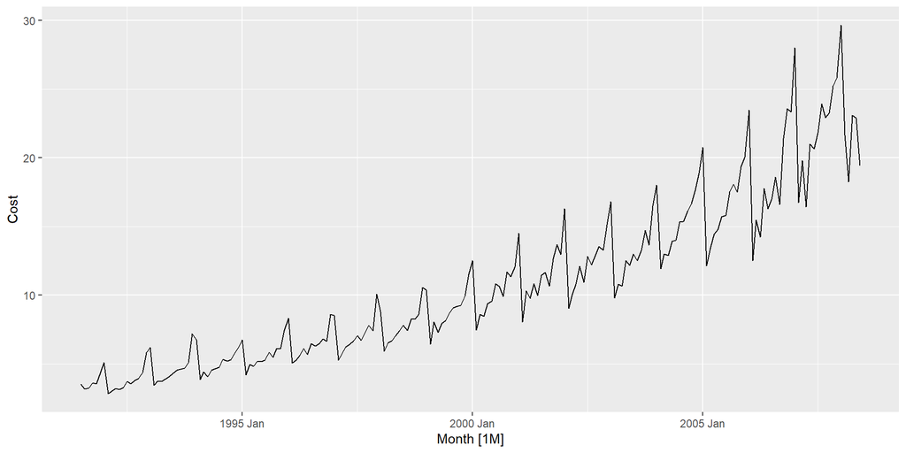

```r
a10 |> autoplot(
  Cost
)
```

## Antidiabetic drug sales (3/4)

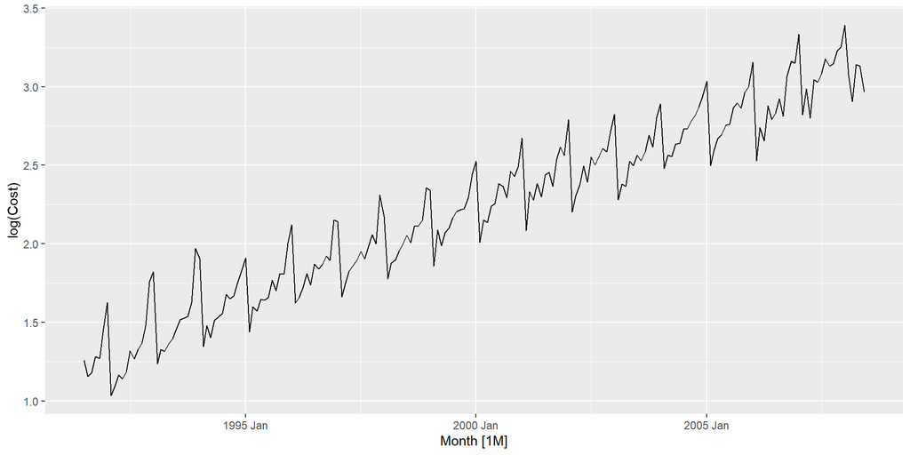

```r
a10 |> autoplot(
  log(Cost)
)
```

## Antidiabetic drug sales (4/4)

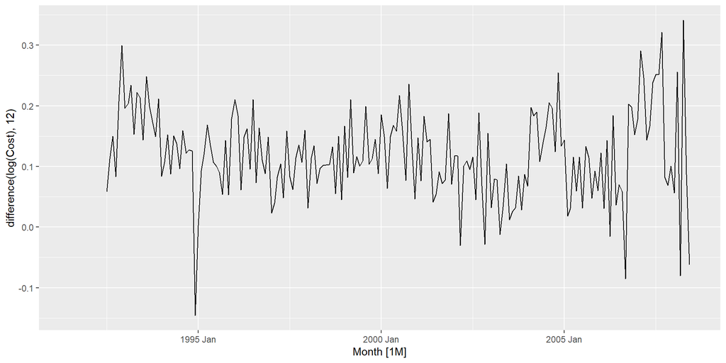

```r
a10 |> autoplot(
  log(Cost) |> difference(12)
)
```

## Cortecosteroid drug sales (1/6)

```r
h02 <- PBS |>
  filter(ATC2 == "H02") |>
  summarise(Cost = sum(Cost)/1e6)
```

## Cortecosteroid drug sales (2/6)

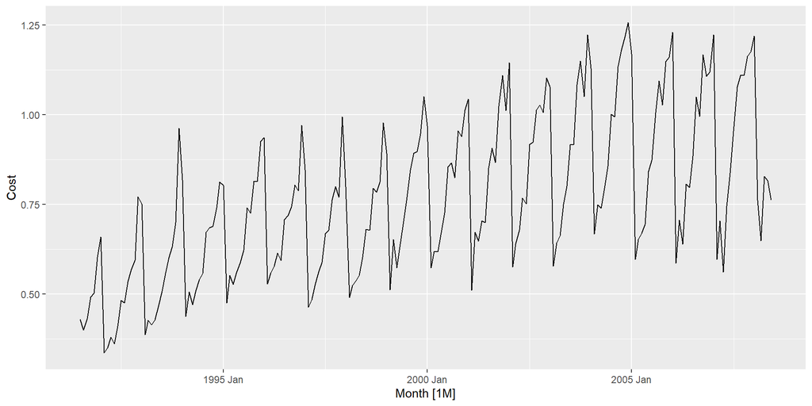

```r
h02 |> autoplot(
  Cost
)
```

## Cortecosteroid drug sales (3/6)

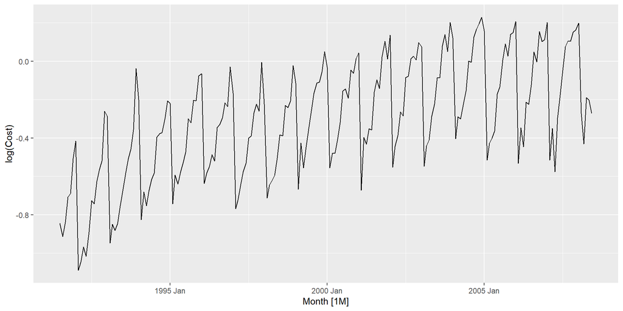

```r
h02 |> autoplot(
  log(Cost)
)
```

## Cortecosteroid drug sales (4/6)

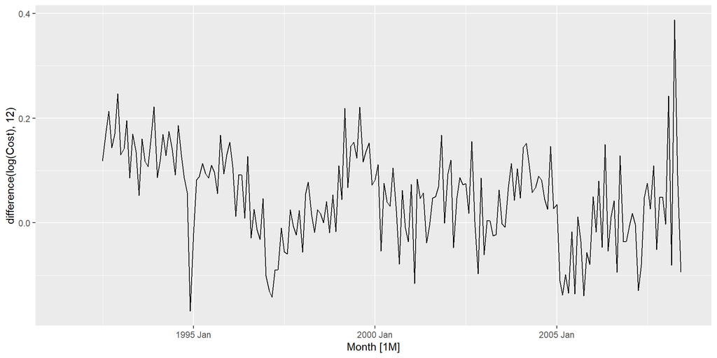

```r
h02 |> autoplot(
  log(Cost) |> difference(12)
)
```

## Cortecosteroid drug sales (5/6)

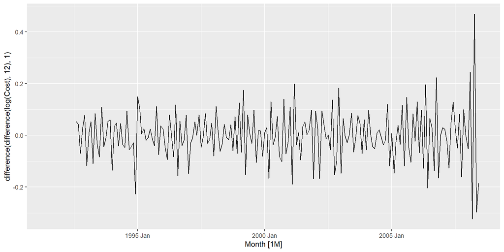

```r
h02 |> autoplot(
  log(Cost) |> difference(12) |> difference(1)
)
```

## Cortecosteroid drug sales (6/6)

- Seasonally differenced series is closer to being stationary.
- Remaining non-stationarity can be removed with further first difference.

. . .

If $y'_t = y_t - y_{t-12}$ denotes seasonally differenced series, then twice-differenced series is

$$\begin{align*}
y^*_t &= y'_t - y'_{t-1} \\
&= (y_t - y_{t-12}) - (y_{t-1} - y_{t-13}) \\
&= y_t - y_{t-1} - y_{t-12} + y_{t-13}\: .
\end{align*}$$

## Seasonal differencing

When both seasonal and first differences are applied

- it makes no difference which is done first—the result will be the same.
- If seasonality is strong, we recommend that seasonal differencing be done first because sometimes the resulting series will be stationary and there will be no need for further first difference.

. . .

It is important that if differencing is used, the differences are interpretable.

## Interpretation of differencing

- first differences are the change between **one observation and the next**;
- seasonal differences are the change between **one year to the next**.

. . .

But taking lag 3 differences for yearly data, for example, results in a model which cannot be sensibly interpreted.

## Unit root tests

**Statistical tests to determine the required order of differencing.**

1. Augmented Dickey Fuller test: null hypothesis is that the data are non-stationary and non-seasonal.
2. Kwiatkowski-Phillips-Schmidt-Shin (KPSS) test: null hypothesis is that the data are stationary and non-seasonal.
3. Other tests available for seasonal data.

We will use the KPSS test.

## KPSS test

```r
google_2018 |>
  features(Close, unitroot_kpss)
```

```
# A tibble: 1 × 3
  Symbol kpss_stat kpss_pvalue
  <chr>      <dbl>       <dbl>
1 GOOG       0.573      0.0252
```

```r
google_2018 |>
  features(Close, unitroot_ndiffs)
```

```
# A tibble: 1 × 2
  Symbol ndiffs
  <chr>   <int>
1 GOOG        1
```

## Automatically selecting differences (1/3)

STL decomposition: $y_t = T_t+S_t+R_t$

Seasonal strength $F_s = \max\big(0, 1-\frac{\text{Var}(R_t)}{\text{Var}(S_t+R_t)}\big)$

If $F_s > 0.64$, do one seasonal difference.

## Automatically selecting differences (2/3)

```r
h02 |> mutate(log_sales = log(Cost)) |>
  features(log_sales, list(unitroot_nsdiffs, feat_stl))
```

```
# A tibble: 1 × 10
  nsdiffs trend_strength seasonal_strength_year seasonal_peak_year seasonal_trough_year
    <int>          <dbl>                  <dbl>              <dbl>                <dbl>
1       1          0.957                  0.955                  6                    8
# ℹ 5 more variables: spikiness <dbl>, linearity <dbl>, curvature <dbl>,
#   stl_e_acf1 <dbl>, stl_e_acf10 <dbl>
```

## Automatically selecting differences (3/3)

```r
h02 |> mutate(log_sales = log(Cost)) |>
  features(log_sales, unitroot_nsdiffs)
```

```
# A tibble: 1 × 1
  nsdiffs
    <int>
1       1
```

```r
h02 |> mutate(d_log_sales = difference(log(Cost), 12)) |>
  features(d_log_sales, unitroot_ndiffs)
```

```
# A tibble: 1 × 1
  ndiffs
   <int>
1      1
```

## Your turn

For the `tourism` dataset, compute the total number of trips and find an appropriate differencing (after transformation if necessary) to obtain stationary data.

## Backshift notation (1/4)

A very useful notational device is the backward shift operator, $B$, which is used as follows:

$$B y_{t} = y_{t - 1}$$

. . .

In other words, $B$, operating on $y_{t}$, has the effect of **shifting the data back one period**.

. . .

Two applications of $B$ to $y_{t}$ **shifts the data back two periods**:
$$B(By_{t}) = B^{2}y_{t} = y_{t-2}$$

. . .

For monthly data, if we wish to shift attention to “the same month last year”, then $B^{12}$ is used, and the notation is $B^{12}y_{t} = y_{t-12}$.

## Backshift notation (2/4)

The backward shift operator is convenient for describing the process of *differencing*.

A first-order difference can be written as
$$y'_{t} = y_{t} - y_{t-1} = y_t - By_{t} = (1 - B)y_{t}$$

. . .

Similarly, if second-order differences (i.e., first differences of first differences) have to be computed, then:

$$y''_{t} = y_{t} - 2y_{t - 1} + y_{t - 2} = (1 - B)^{2} y_{t}$$

## Backshift notation (3/4)

- Second-order difference is denoted $(1- B)^{2}$.
- *Second-order difference* is not the same as a *second difference*, which would be denoted $1- B^{2}$;
- In general, a $d$th-order difference can be written as

. . .

$$(1 - B)^{d} y_{t}$$

- A seasonal difference followed by a first difference can be written as

. . .

$$(1-B)(1-B^m)y_t$$

## Backshift notation (4/4)

The “backshift” notation is convenient because the terms can be multiplied together to see the combined effect.

$$\begin{align*}
(1-B)(1-B^m)y_t & = (1 - B - B^m + B^{m+1})y_t \\
& = y_t-y_{t-1}-y_{t-m}+y_{t-m-1}.
\end{align*}$$

For monthly data, $m=12$ and we obtain the same result as earlier.

# Non-seasonal ARIMA models

## Autoregressive models

**Autoregressive (AR) models:**

$$y_{t} = c + \phi_{1}y_{t - 1} + \phi_{2}y_{t - 2} + \cdots + \phi_{p}y_{t - p} + \epsilon_{t},$$
where $\epsilon_t$ is white noise. This is a multiple regression with **lagged values** of $y_t$ as predictors.

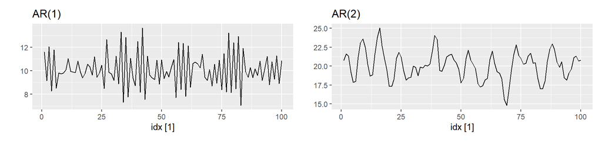

## AR(1) model

$y_{t} = 18 -0.8 y_{t - 1} + \epsilon_{t},$ $\epsilon_t\sim N(0,1)$, $T=100$.

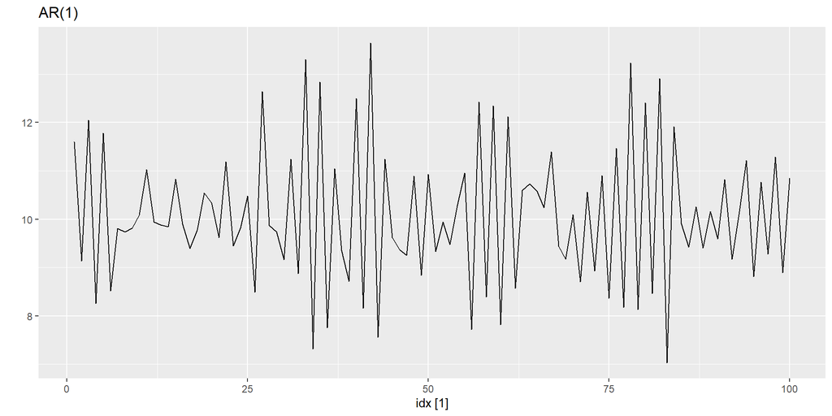

## AR(1) model

$y_{t} = c + \phi_1 y_{t - 1} + \epsilon_{t}$

- When $\phi_1=0$, $y_t$ is **equivalent to WN**
- When $\phi_1=1$ and $c=0$, $y_t$ is **equivalent to a RW**
- When $\phi_1=1$ and $c\ne0$, $y_t$ is **equivalent to a RW with drift**
- When $\phi_1<0$, $y_t$ tends to **oscillate between positive and negative values**.

## AR(2) model

$y_t = 8 + 1.3y_{t-1} - 0.7 y_{t-2} + \epsilon_t$ where $\epsilon_t\sim N(0,1)$ & $T=100$.

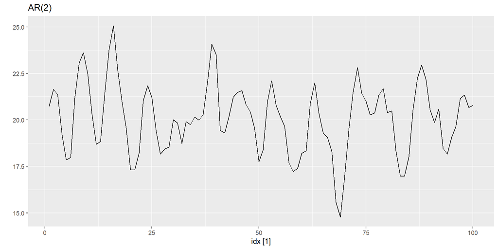

## Stationarity conditions

We normally restrict autoregressive models to stationary data, and then some constraints on the values of the parameters are required.

- For $p=1$: $-1<\phi_1<1$.
- For $p=2$:$-1<\phi_2<1\qquad \phi_2+\phi_1 < 1 \qquad \phi_2 -\phi_1 < 1$.
- More complicated conditions hold for $p\ge3$.
- Estimation software takes care of this.

## Moving Average (MA) models

**Moving Average (MA) models:**

$$y_{t} = c + \epsilon_t + \theta_{1}\varepsilon_{t - 1} + \theta_{2}\varepsilon_{t - 2} + \cdots + \theta_{q}\varepsilon_{t - q},$$

where $\epsilon_t$ is white noise. This is a multiple regression with **past *errors*** as predictors. *Don’t confuse this with moving average smoothing!*

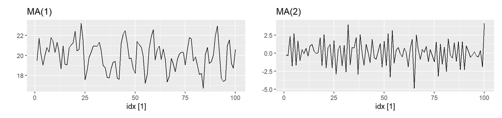

## MA(1) model

$y_t = 20 + \epsilon_t + 0.8 \varepsilon_{t-1}$ where $\epsilon_t\sim N(0,1)$ & $T=100$.

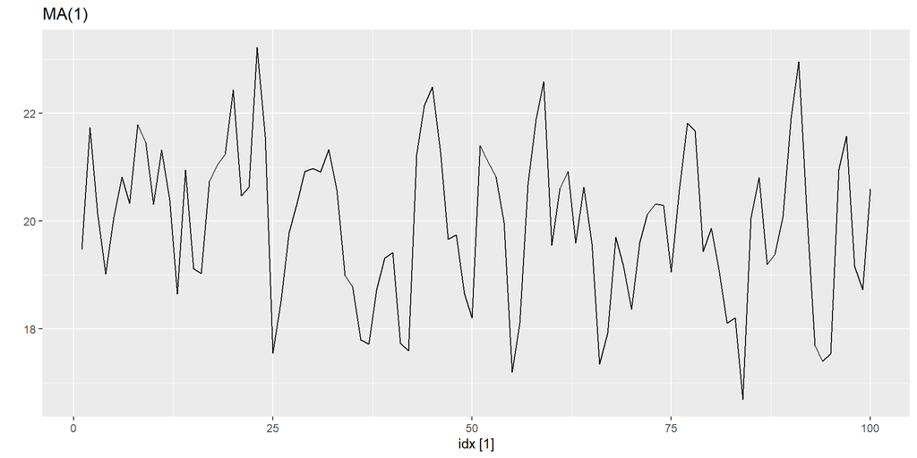

## MA(2) model

$y_t = \epsilon_t -\varepsilon_{t-1} + 0.8 \varepsilon_{t-2}$ where $\epsilon_t\sim N(0,1)$ & $T=100$.

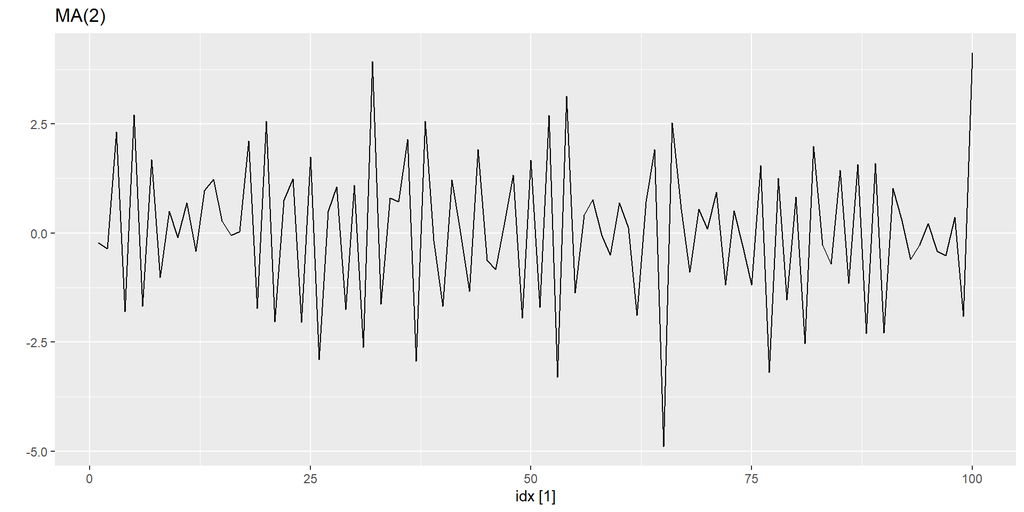

## MA($\infty$) models

It is possible to write any stationary AR($p$) process as an MA($\infty$) process.

**Example: AR(1)**
$$\begin{align*}
y_t &= \phi_1y_{t-1} + \epsilon_t\\
&= \phi_1(\phi_1y_{t-2} + \varepsilon_{t-1}) + \epsilon_t\\
&= \phi_1^2y_{t-2} + \phi_1 \varepsilon_{t-1} + \epsilon_t\\
&= \phi_1^3y_{t-3} + \phi_1^2\varepsilon_{t-2} + \phi_1 \varepsilon_{t-1} + \epsilon_t\\
&\dots
\end{align*}$$
Provided $-1<\phi_1<1$:
$$y_t = \epsilon_t + \phi_1\varepsilon_{t-1}+ \phi_1^2\varepsilon_{t-2}+ \phi_1^3\varepsilon_{t-3} + \cdots$$

## Invertibility

- Any MA($q$) process can be written as an AR($\infty$) process if we impose some constraints on the MA parameters.
- Then the MA model is called “invertible”.
- Invertible models have some mathematical properties that make them easier to use in practice.

## Invertibility

**General condition for invertibility** Complex roots of $1+\theta_1 z + \theta_2 z^2 + \dots + \theta_qz^q$ lie outside the unit circle on the complex plane.

- For $q=1$: $-1<\theta_1<1$.
- For $q=2$:$-1<\theta_2<1\qquad \theta_2+\theta_1 >-1 \qquad \theta_1 -\theta_2 < 1$.
- More complicated conditions hold for $q\ge3$.
- Estimation software takes care of this.

## ARMA models

**Autoregressive Moving Average models:**

$$y_{t} = c + \phi_{1}y_{t - 1} + \cdots + \phi_{p}y_{t - p} + \theta_{1}\varepsilon_{t - 1} + \cdots + \theta_{q}\varepsilon_{t - q} + \epsilon_{t}.$$

- Predictors include both **lagged values of $y_t$ and lagged errors.**
- Conditions on AR coefficients ensure stationarity.
- Conditions on MA coefficients ensure invertibility.

## Autoregressive Integrated Moving Average models

- Combine ARMA model with **differencing**.
- $(1-B)^d y_t$ follows an ARMA model.

## ARIMA models

**Autoregressive Integrated Moving Average models**

**ARIMA($p, d, q$) model**

| **Component** | **Description** |
| --- | --- |
| **AR** | $p =$ order of the autoregressive part |
| **I** | $d =$ degree of first differencing involved |
| **MA** | $q =$ order of the moving average part |

- White noise model: ARIMA(0,0,0)
- Random walk: ARIMA(0,1,0) with no constant
- Random walk with drift: ARIMA(0,1,0) with a constant (c)
- AR($p$): ARIMA($p$,0,0)
- MA($q$): ARIMA(0,0,$q$)

## Backshift notation for ARIMA

**ARMA model**

$$\begin{aligned}
y_{t} &= c + \phi_{1}By_{t} + \cdots + \phi_pB^py_{t}
+ \epsilon_{t} + \theta_{1}B\epsilon_{t} + \cdots + \theta_qB^q\epsilon_{t} \\
\text{or}\quad
& (1-\phi_1B - \cdots - \phi_p B^p) y_t = c + (1 + \theta_1 B + \cdots + \theta_q B^q)\epsilon_t
\end{aligned}$$

**ARIMA(1,1,1) model**

$$\begin{array}{c c c c}
(1 - \phi_{1} B) & (1 - B) y_{t} &= &c + (1 + \theta_{1} B) \epsilon_{t}\\
{\uparrow} & {\uparrow} & &{\uparrow}\\
{\text{AR(1)}} & {\text{First}} & &{\text{MA(1)}}\\
& \text{difference}\\
\end{array}$$

. . .

$$y_t = c + y_{t-1} + \phi_1 y_{t-1}- \phi_1 y_{t-2} + \theta_1\varepsilon_{t-1} + \epsilon_t$$

## General ARIMA Equation

$$\underbrace{(1 - \phi_1 B - \cdots - \phi_p B^p)}_{\text{AR}(p)}
\quad
\underbrace{(1 - B)^d}_{d \text{ differences}}y_t = c+
\quad
\underbrace{(1 + \theta_1 B + \cdots + \theta_q B^q)}_{\text{MA}(q)}\epsilon_t$$

## R model

**Intercept Form**

$(1-\phi_1B - \cdots - \phi_p B^p) y_t' = c + (1 + \theta_1 B + \cdots + \theta_q B^q)\epsilon_t$

. . .

**Mean Form**

$(1-\phi_1B - \cdots - \phi_p B^p)(y_t' - \mu) = (1 + \theta_1 B + \cdots + \theta_q B^q)\epsilon_t$

- $y_t' = (1-B)^d y_t$
- $\mu$ is the mean of $y_t'$.
- $c = \mu(1-\phi_1 - \cdots - \phi_p )$.
- `fable` uses the intercept form

## Egyptian exports

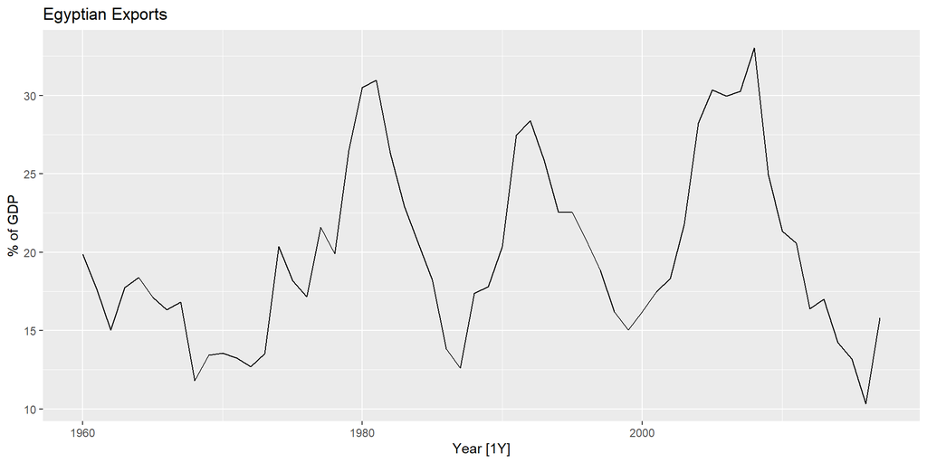

```r
global_economy |>
  filter(Code == "EGY") |>
  autoplot(Exports) +
  labs(y = "% of GDP", title = "Egyptian Exports")
```

## Egyptian exports

```r
fit <- global_economy |> filter(Code == "EGY") |>
  model(ARIMA(Exports))
report(fit)
```

```
Series: Exports
Model: ARIMA(2,0,1) w/ mean

Coefficients:
         ar1      ar2      ma1  constant
      1.6764  -0.8034  -0.6896    2.5623
s.e.  0.1111   0.0928   0.1492    0.1161

sigma^2 estimated as 8.046:  log likelihood=-141.57
AIC=293.13   AICc=294.29   BIC=303.43
```

## ARIMA(2,0,1) model:

$$y_t = 2.56
+ 1.68 y_{t-1}
-0.80 y_{t-2}
-0.69 \varepsilon_{t-1}
+ \epsilon_{t},$$

where $\epsilon_t$ is white noise with a standard deviation of $2.837 = \sqrt{8.046}$.

## Egyptian exports

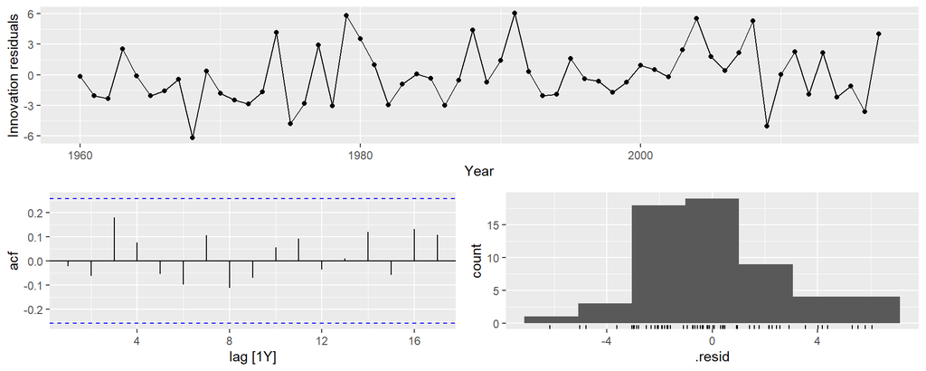

```r
gg_tsresiduals(fit)
```

## Egyptian exports

```r
augment(fit) |>
  features(.innov, ljung_box, lag = 10, dof = 4)
```

```
# A tibble: 1 × 4
  Country          .model         lb_stat lb_pvalue
  <fct>            <chr>            <dbl>     <dbl>
1 Egypt, Arab Rep. ARIMA(Exports)    5.78     0.448
```

## Egyptian exports

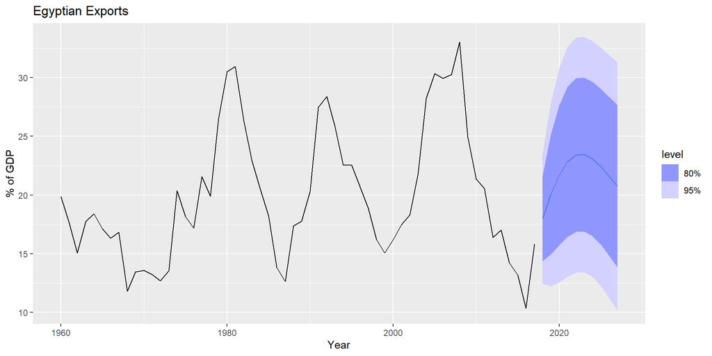

```r
fit |> forecast(h=10) |>
  autoplot(global_economy) +
  labs(y = "% of GDP", title = "Egyptian Exports")
```

## Understanding ARIMA models

The constant c has an important effect on the long-term forecasts obtained from these models.

- If $c=0$ and $d=0$, the long-term forecasts will go to zero.
- If $c=0$ and $d=1$, the long-term forecasts will go to a non-zero constant.
- If $c=0$ and $d=2$, the long-term forecasts will follow a straight line.
- If $c\ne0$ and $d=0$, the long-term forecasts will go to the mean of the data.
- If $c\ne0$ and $d=1$, the long-term forecasts will follow a straight line.
- If $c\ne0$ and $d=2$, the long-term forecasts will follow a quadratic trend. (This is not recommended, and `fable` will not permit it.)

## Understanding ARIMA models

**Forecast variance and $d$**

- The higher the value of $d$, the more rapidly the prediction intervals increase in size.
- For $d=0$, the long-term forecast standard deviation will go to the standard deviation of the historical data.

. . .

**Cyclic behaviour**

- For cyclic forecasts, $p\ge2$ and some restrictions on coefficients are required.
- If $p=2$, we need $\phi_1^2+4\phi_2<0$. Then average cycle of length
  $$(2\pi)/\left[\text{arc cos}(-\phi_1(1-\phi_2)/(4\phi_2))\right].$$

# Estimation and order selection

## Maximum likelihood estimation

Having identified the model order, we need to estimate the parameters $c$, $\phi_1,\dots,\phi_p$, $\theta_1,\dots,\theta_q$.

- MLE is very similar to least squares estimation obtained by minimizing

. . .

$$\sum_{t-1}^T e_t^2$$

- The `ARIMA()` function allows LS or MLE estimation.
- Non-linear optimization must be used in either case.
- Different software will give different estimates.

## Partial autocorrelations

**Partial autocorrelations** measure relationship  
between $y_{t}$ and $y_{t - k}$, when the effects of other time lags — $1, 2, 3, \dots, k - 1$ — are removed.

$$\begin{aligned}
\alpha_k &= k\text{th partial autocorrelation coefficient}\\
&= \text{equal to the estimate of } \phi_k \text{ in regression:}\\
& y_t = c + \phi_1 y_{t-1} + \phi_2 y_{t-2} + \dots + \phi_k y_{t-k} + \epsilon_t.
\end{aligned}$$

- Varying number of terms on RHS gives $\alpha_k$ for different values of $k$.
- $\alpha_1=\rho_1$
- same critical values of $\pm 1.96/\sqrt{T}$ as for ACF.
- Last significant $\alpha_k$ indicates the order of an AR model.

## Egyptian exports

```r
egypt <- global_economy |> filter(Code == "EGY")
egypt |> ACF(Exports) |> autoplot()
egypt |> PACF(Exports) |> autoplot()
```

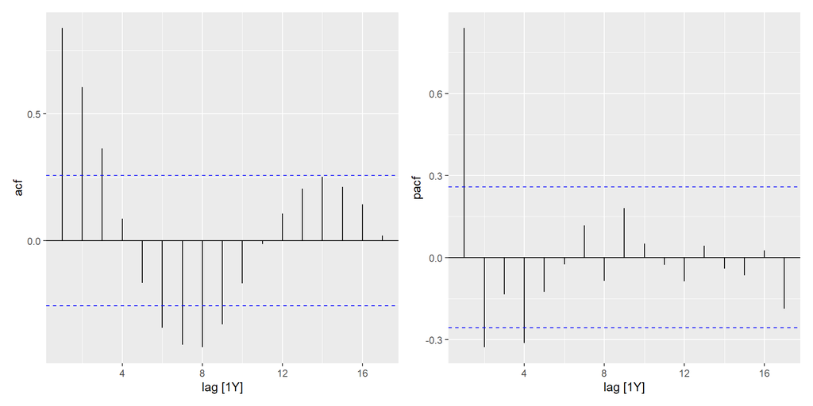

## Egyptian exports

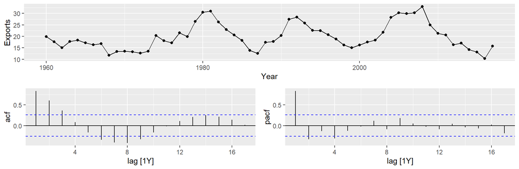

```r
global_economy |> filter(Code == "EGY") |>
  gg_tsdisplay(Exports, plot_type='partial')
```

## ACF and PACF interpretation (1/4)

**AR(1)**

$$\begin{aligned}
\rho_k &= \phi_1^k \text{ for } k=1,2,\dots; \\
\alpha_1 &= \phi_1 \\
\alpha_k &= 0 \text{ for } k=2,3,\dots.
\end{aligned}$$

So we have an AR(1) model when

- autocorrelations exponentially decay
- there is a single significant partial autocorrelation.

## ACF and PACF interpretation (2/4)

**AR($p$)**

- ACF dies out in an exponential or damped sine-wave manner
- PACF has all zero spikes beyond the $p$th spike

. . .

So we have an AR($p$) model when

- the ACF is exponentially decaying or sinusoidal
- there is a significant spike at lag $p$ in PACF, but none beyond $p$

## ACF and PACF interpretation (3/4)

**MA(1)**

$$\begin{aligned}
\rho_1 &= \theta_1/(1 + \theta_1^2) \qquad \rho_k = 0 \qquad \text{for } k=2,3,\dots; \\
\alpha_k &= -(-\theta_1)^k/(1 + \theta_1^2 + \dots + \theta_1^{2k})
\end{aligned}$$

So we have an MA(1) model when

- the PACF is exponentially decaying and
- there is a single significant spike in ACF

## ACF and PACF interpretation (4/4)

**MA($q$)**

- PACF dies out in an exponential or damped sine-wave manner
- ACF has all zero spikes beyond the $q$th spike

. . .

So we have an MA($q$) model when

- the PACF is exponentially decaying or sinusoidal
- there is a significant spike at lag $q$ in ACF, but none beyond $q$

## Information criteria

**Akaike’s Information Criterion (AIC):**

$$\text{AIC} = -2 \log(L) + 2(p+q+k+1),$$

where $L$ is the likelihood of the data, $k=1$ if $c \ne 0$ and $k=0$ if $c=0$.

**Corrected AIC:**

$$\text{AICc} = \text{AIC} + \frac{2(p+q+k+1)(p+q+k+2)}{T-p-q-k-2}.$$

**Bayesian Information Criterion:**

$$\text{BIC} = \text{AIC} + \log(T)-2.$$

. . .

Good models are obtained by minimizing either the AIC, **AICc** or **BIC**. Book authors’ preference is to use the **AICc**.